# Tree Prediction

```python
import pandas as pd
import numpy as np
import seaborn as sb
import matplotlib.pyplot as plt
```

```python
dt=pd.read_csv('Tree_Dataset.csv')
dt.head()
```

|  | Unnamed: 0 | X | No | Plot | Subplot | Species | Light_ISF | Light_Cat | Core | Soil | ... | PlantDate | AMF | EMF | Phenolics | Lignin | NSC | Census | Time | Event | Harvest |
| --- | --- | --- | --- | --- | --- | --- | --- | --- | --- | --- | --- | --- | --- | --- | --- | --- | --- | --- | --- | --- | --- |
| 0 | 1 | 0 | 126 | 1 | C | Acer saccharum | 0.106 | Med | 2017 | Prunus serotina | ... | 6/11/18 | 22.00 | 1.0 | -0.56 | 13.86 | 12.15 | 4 | 14.0 | 1.0 | X |
| 1 | 2 | 1 | 11 | 1 | C | Quercus alba | 0.106 | Med | 2017 | Quercus rubra | ... | 5/25/18 | 15.82 | 0.0 | 5.19 | 20.52 | 19.29 | 33 | 115.5 | 0.0 | X |
| 2 | 3 | 2 | 12 | 1 | C | Quercus rubra | 0.106 | Med | 2017 | Prunus serotina | ... | 5/31/18 | 24.45 | 1.0 | 3.36 | 24.74 | 15.01 | 18 | 63.0 | 1.0 | X |
| 3 | 4 | 3 | 2823 | 7 | D | Acer saccharum | 0.080 | Med | 2016 | Prunus serotina | ... | 6/11/18 | 22.23 | 1.0 | -0.71 | 14.29 | 12.36 | 4 | 14.0 | 1.0 | X |
| 4 | 5 | 4 | 5679 | 14 | A | Acer saccharum | 0.060 | Low | 2017 | Prunus serotina | ... | 6/11/18 | 21.15 | 1.0 | -0.58 | 10.85 | 11.20 | 4 | 14.0 | 1.0 | X |

5 rows × 25 columns

```python
dt.describe()
```

|  | Unnamed: 0 | X | No | Plot | Light_ISF | Core | AMF | EMF | Phenolics | Lignin | NSC | Census | Time | Event |
| --- | --- | --- | --- | --- | --- | --- | --- | --- | --- | --- | --- | --- | --- | --- |
| count | 2783.000000 | 2783.000000 | 2783.000000 | 2783.000000 | 2783.000000 | 2783.000000 | 2783.000000 | 2783.000000 | 2783.000000 | 2783.000000 | 2783.000000 | 2783.000000 | 2783.000000 | 2783.000000 |
| mean | 1392.000000 | 1391.000000 | 3914.513834 | 9.561624 | 0.085707 | 2016.648940 | 20.553069 | 0.570453 | 1.933105 | 15.759792 | 14.219641 | 15.282070 | 53.487244 | 0.570453 |
| std | 803.527224 | 803.527224 | 2253.515063 | 5.203659 | 0.025638 | 0.477387 | 12.309587 | 0.495012 | 1.969842 | 6.779607 | 4.298271 | 9.166555 | 32.082942 | 0.495012 |
| min | 1.000000 | 0.000000 | 3.000000 | 1.000000 | 0.032000 | 2016.000000 | 0.000000 | 0.000000 | -1.350000 | 2.230000 | 4.300000 | 4.000000 | 14.000000 | 0.000000 |
| 25% | 696.500000 | 695.500000 | 1971.000000 | 5.000000 | 0.066000 | 2016.000000 | 13.400000 | 0.000000 | 0.170000 | 10.355000 | 11.605000 | 7.000000 | 24.500000 | 0.000000 |
| 50% | 1392.000000 | 1391.000000 | 3932.000000 | 10.000000 | 0.082000 | 2017.000000 | 18.000000 | 1.000000 | 0.750000 | 14.040000 | 12.660000 | 13.000000 | 45.500000 | 1.000000 |
| 75% | 2087.500000 | 2086.500000 | 5879.000000 | 14.000000 | 0.100000 | 2017.000000 | 24.445000 | 1.000000 | 3.780000 | 21.115000 | 17.275000 | 18.000000 | 63.000000 | 1.000000 |
| max | 2783.000000 | 2782.000000 | 7772.000000 | 18.000000 | 0.161000 | 2017.000000 | 100.000000 | 1.000000 | 6.100000 | 32.770000 | 29.450000 | 33.000000 | 115.500000 | 1.000000 |

```python
dt.dtypes
```

```
Unnamed: 0       int64
X                int64
No               int64
Plot             int64
Subplot         object
Species         object
Light_ISF      float64
Light_Cat       object
Core             int64
Soil            object
Adult           object
Sterile         object
Conspecific     object
Myco            object
SoilMyco        object
PlantDate       object
AMF            float64
EMF            float64
Phenolics      float64
Lignin         float64
NSC            float64
Census           int64
Time           float64
Event          float64
Harvest         object
dtype: object
```

```python
dt.isna().sum()
```

```
Unnamed: 0     0
X              0
No             0
Plot           0
Subplot        0
Species        0
Light_ISF      0
Light_Cat      0
Core           0
Soil           0
Adult          0
Sterile        0
Conspecific    0
Myco           0
SoilMyco       0
PlantDate      0
AMF            0
EMF            0
Phenolics      0
Lignin         0
NSC            0
Census         0
Time           0
Event          0
Harvest        0
dtype: int64
```

**From the Observation above, we can tell the data was pretty cleaned. So let's get to work!**

# Project Title: Comprehensive Analysis and Prediction of Tree Event Occurrences in Diverse Environmental Conditions

**Objective**:\ This project aims to conduct a detailed analysis of tree growth and survival, focusing on predicting tree event occurrences (main mission) while also exploring various ecological and environmental factors (side missions) that influence tree dynamics in a forest ecosystem.

## Main Mission - Event Prediction Analysis

- **Goal**: Develop a predictive model to forecast tree event occurrences.
- **Techniques**: Utilize Machine Learning algorithms like Logistic Regression, Decision Trees, or Random Forest to predict the 'Event' variable based on available features.

## **Side Missions - Supplementary Analyses**:

1. Sp**ecies Distribution Analysis**:
   - **Goal**: Assess the distribution and diversity of tree species in the dataset.
   - **Techniques**: Data Visualization (Pie Charts, Bar Graphs), Descriptive Statistics.
2. **Light Conditions vs Growth Analysis**:
   - **Goal**: Understand the impact of light conditions on tree growth and health.
   - **Techniques**: Correlation and Regression Analysis, Data Visualization.
3. **Soil Type Impact Study**:
   - **Goal**: Examine the influence of different soil types on tree characteristics.
   - **Techniques**: ANOVA, Multivariate Analysis.
4. **Time Series Analysis of Census Data**:
   - **Goal**: Explore temporal patterns in tree growth and related phenomena.
   - **Techniques**: Time Series Analysis, Trend Visualization.
5. **Correlation Analysis between Key Variables**:
   - **Goal**: Investigate relationships between variables like 'AMF', 'EMF', 'Phenolics', etc.
   - **Techniques**: Correlation Matrix, Heat Maps.
6. **Cluster Analysis for Pattern Identification**:
   - **Goal**: Identify patterns or groups based on tree characteristics.
   - **Techniques**: K-Means Clustering, Hierarchical Clustering.

### **Expected Outcome**:

- A comprehensive understanding of the factors affecting tree growth, health, and event occurrences.
- Practical predictive models for forecasting tree events.
- Identification of key patterns and relationships among various ecological factors and tree characteristics.

### Species Distribution Analysis

```python
Species_ct=dt['Species'].value_counts()
Species_ct
```

```
Acer saccharum     751
Prunus serotina    749
Quercus alba       673
Quercus rubra      610
Name: Species, dtype: int64
```

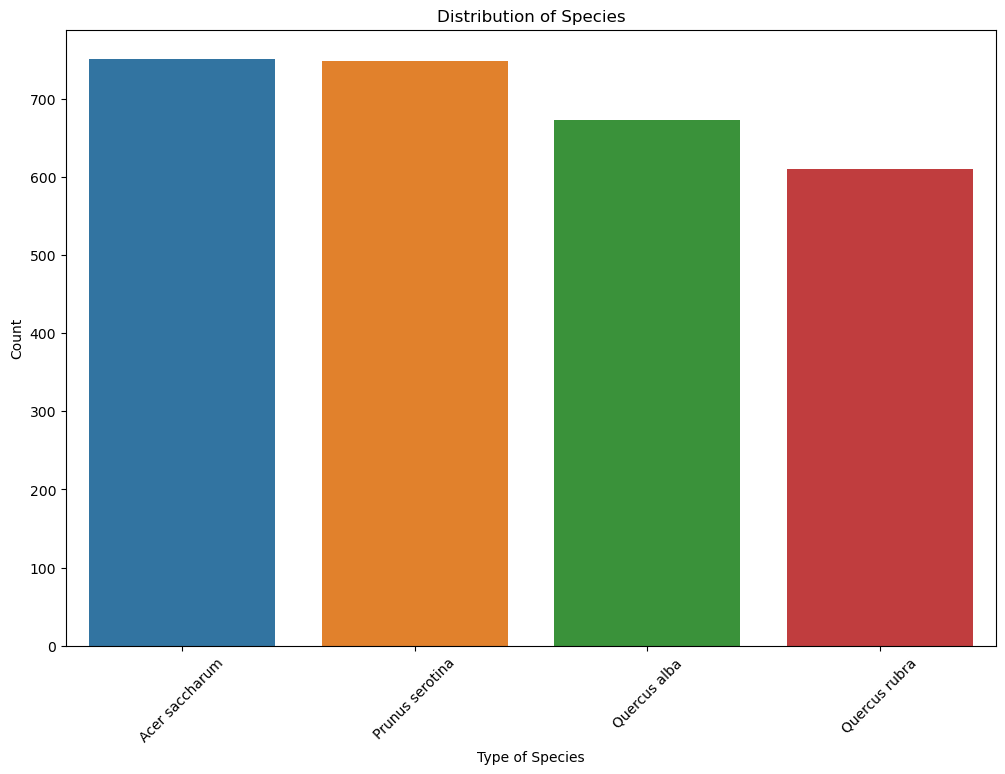

```python
plt.figure(figsize=(12, 8))
sb.barplot(x=Species_ct.index,y=Species_ct.values)
plt.xlabel('Type of Species')
plt.ylabel('Count')
plt.title('Distribution of Species')
plt.xticks(rotation=45)
plt.show()
```

We now knowing there's only 4 types of tree in the dataset, which are Acer saccharum (Sugar Maple), Prunus serotina (Black Cherry), Quercus alba (White Oak), and Quercus rubra (Red Oak). And these four types of tree can tell us that this data are very likely conducted in the region where temperate forest locates, more specificlly this dataset are likely conducted in the Eastern/Northern United States and parts of Canada where these types of tree can be commonly found.

### Light Conditions vs Growth Time Analysis

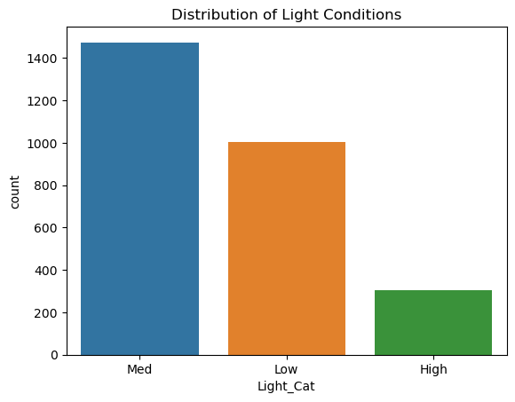

```python
sb.countplot(x='Light_Cat',data=dt)
plt.title('Distribution of Light Conditions')
plt.show()
```

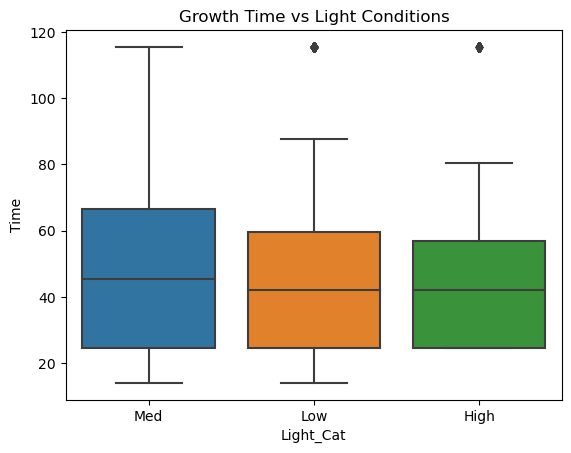

```python
sb.boxplot(x='Light_Cat', y='Time', data=dt)
plt.title('Growth Time vs Light Conditions')
plt.show()
```

Overall, tree under the Medium light condition has longer growth time while that under low and high ligh condition only occur much higher growth time occasionally.

```python
import statsmodels.api as sm
from statsmodels.formula.api import ols
lt_mdl=ols('Time~C(Light_Cat)',data=dt).fit()
anova_table = sm.stats.anova_lm(lt_mdl, typ=2)
anova_table
```

|  | sum_sq | df | F | PR(>F) |
| --- | --- | --- | --- | --- |
| C(Light_Cat) | 1.049019e+04 | 2.0 | 5.110771 | 0.006088 |
| Residual | 2.853065e+06 | 2780.0 | NaN | NaN |

**Null Hypothesis**: There are no differences in the means of the 'Time' variable across the different levels of 'Light_Cat'.\ **Alternative Hypothesis**: There are significance in the means of the 'Time' variable across the different levels of 'Light_Cat'.\ **Result**: The P-value much fewer than 0.01, suggesting that there's a statistically significant effect of light conditions on growth time, with at least one group's mean significantly different from the others. Given the low p-value, we reject the null hypothesis of equal means across light conditions.

### Soil Type Impact Study

```python
Soil_ct=dt['Soil'].value_counts()
Soil_ct
```

```
Sterile                  423
Prunus serotina          413
Quercus rubra            402
Acer saccharum           397
Populus grandidentata    391
Quercus alba             381
Acer rubrum              376
Name: Soil, dtype: int64
```

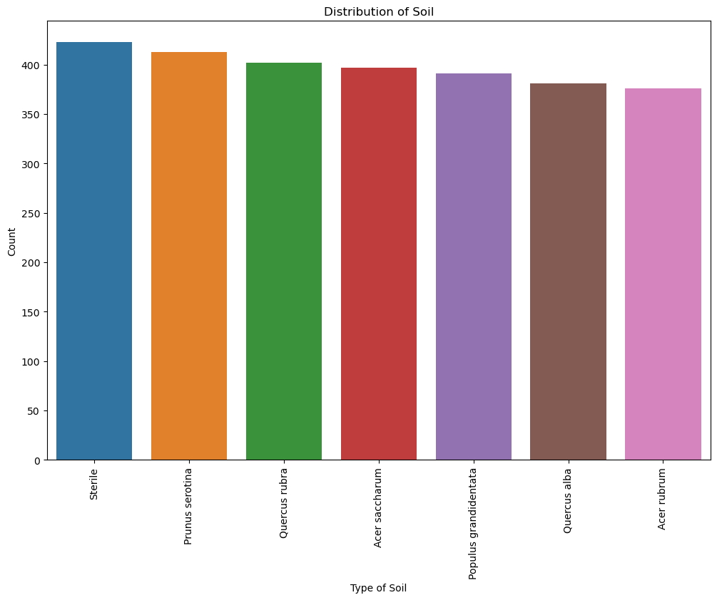

```python
plt.figure(figsize=(12, 8))
sb.barplot(x=Soil_ct.index,y=Soil_ct.values)
plt.xlabel('Type of Soil')
plt.ylabel('Count')
plt.title('Distribution of Soil')
plt.xticks(rotation=90)
plt.show()
```

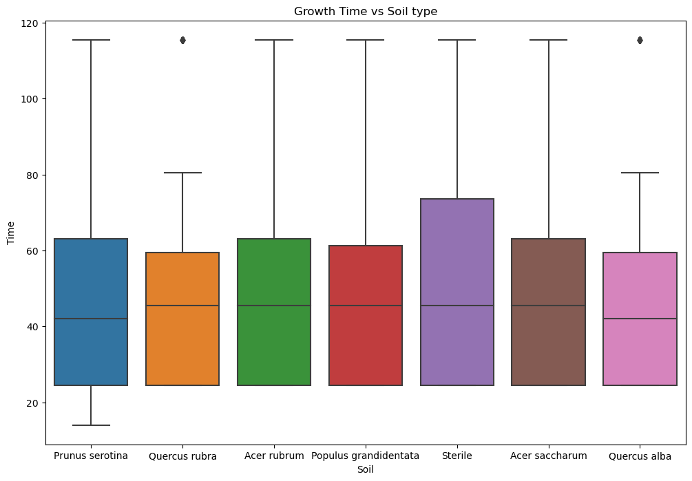

```python
plt.figure(figsize=(12, 8))
sb.boxplot(x='Soil', y='Time', data=dt)
plt.title('Growth Time vs Soil type')
plt.show()
```

From the graphic, we can tell that the type of soil might be impact on the time of tree growing. In order to check the validity of this assumption, the ANOVA test can be helpful.

```python
st_mdl=ols('Time~C(Soil)',data=dt).fit()
st_anova_table = sm.stats.anova_lm(st_mdl, typ=2)
st_anova_table
```

|  | sum_sq | df | F | PR(>F) |
| --- | --- | --- | --- | --- |
| C(Soil) | 8.967027e+03 | 6.0 | 1.45336 | 0.190388 |
| Residual | 2.854588e+06 | 2776.0 | NaN | NaN |

**Null Hypothesis**: There are no differences in the means of the 'Time' variable across the different types of 'Soil'.\ **Alternative Hypothesis**: There are significance in the means of the 'Time' variable across the different types of 'Soil'.\ **Result**: Since the P-value is much greater than 0.05, which means we have not enough evidence to reject the null hypothesis that there are no differences between types of soil, we now can say the soil variable might have no impact on the time of tree growing.

### Time Series Analysis of Census Data

```python
dt['PlantDate']=pd.to_datetime(dt['PlantDate'])
```

```python
date_cen_group=dt.groupby('PlantDate')['Census'].mean()
date_cen_group
```

```
PlantDate
2018-05-10    21.181818
2018-05-17    18.718519
2018-05-18    15.000000
2018-05-22    17.530769
2018-05-23    19.944444
2018-05-24    16.620690
2018-05-25    20.137778
2018-05-29    19.199153
2018-05-30    19.666667
2018-05-31    18.025547
2018-06-01    12.528517
2018-06-04    11.429078
2018-06-05    11.976415
2018-06-06    13.863014
2018-06-07    11.429412
2018-06-08    12.122093
2018-06-11    11.793651
2018-06-12     9.500000
2018-06-15    17.152542
Name: Census, dtype: float64
```

```python
time_dt=dt[['PlantDate','Census']]
time_dt.set_index('PlantDate',inplace=True)
```

```python
mean_census = dt['Census'].mean()
std_dev_census = dt['Census'].std()
```

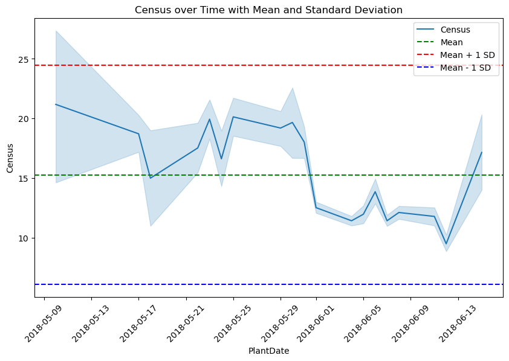

```python
plt.figure(figsize=(10, 6))  # You can adjust the size as needed
sb.lineplot(data=time_dt, x=time_dt.index, y='Census', label='Census')

plt.axhline(mean_census, color='green', linestyle='--', label='Mean')

plt.axhline(mean_census + std_dev_census, color='red', linestyle='--', label='Mean + 1 SD')
plt.axhline(mean_census - std_dev_census, color='blue', linestyle='--', label='Mean - 1 SD')
plt.xticks(rotation=45)
plt.xlabel('PlantDate')
plt.ylabel('Census')
plt.title('Census over Time with Mean and Standard Deviation')
plt.legend()

# Display the plot
plt.show()
```

```python
from statsmodels.tsa.stattools import adfuller
adft = adfuller(time_dt,autolag="AIC")
```

```python
output_dt = pd.DataFrame({"Values":[adft[0],adft[1],adft[2],adft[3], adft[4]['1%'], adft[4]['5%'], adft[4]['10%']]  , "Metric":["Test Statistics","p-value","No. of lags used","Number of observations used",
                                                        "critical value (1%)", "critical value (5%)", "critical value (10%)"]})
print(output_dt)
```

```
         Values                       Metric
0 -6.143147e+00              Test Statistics
1  7.882284e-08                      p-value
2  2.200000e+01             No. of lags used
3  2.760000e+03  Number of observations used
4 -3.432722e+00          critical value (1%)
5 -2.862588e+00          critical value (5%)
6 -2.567328e+00         critical value (10%)
```

**Null Hypothesis**: The time series has a unit root, indicating it is non-stationary.\ **Alternative Hypothesis**: The time series does not have a unit root, indicating it is stationary.\ **Result**: Since the P-value is much lower than 0.05, indicating that the time series here doesn't have unit root and it's stationary.

### Correlation Analysis between Key Variables

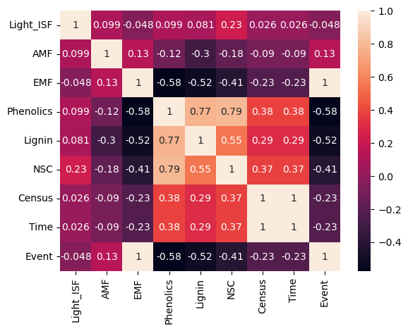

```python
dt_cor=dt[['Light_ISF','AMF','EMF','Phenolics','Lignin','NSC','Census','Time','Event']]
cormat=dt_cor.corr()
sb.heatmap(cormat, annot=True)
```

```python
cormat
```

|  | Light_ISF | AMF | EMF | Phenolics | Lignin | NSC | Census | Time | Event |
| --- | --- | --- | --- | --- | --- | --- | --- | --- | --- |
| Light_ISF | 1.000000 | 0.099120 | -0.048397 | 0.098531 | 0.081305 | 0.227706 | 0.026203 | 0.026203 | -0.048397 |
| AMF | 0.099120 | 1.000000 | 0.134542 | -0.121295 | -0.304034 | -0.181600 | -0.090019 | -0.090019 | 0.134542 |
| EMF | -0.048397 | 0.134542 | 1.000000 | -0.575486 | -0.519618 | -0.409873 | -0.232071 | -0.232071 | 1.000000 |
| Phenolics | 0.098531 | -0.121295 | -0.575486 | 1.000000 | 0.768149 | 0.791244 | 0.379782 | 0.379782 | -0.575486 |
| Lignin | 0.081305 | -0.304034 | -0.519618 | 0.768149 | 1.000000 | 0.546625 | 0.293374 | 0.293374 | -0.519618 |
| NSC | 0.227706 | -0.181600 | -0.409873 | 0.791244 | 0.546625 | 1.000000 | 0.368411 | 0.368411 | -0.409873 |
| Census | 0.026203 | -0.090019 | -0.232071 | 0.379782 | 0.293374 | 0.368411 | 1.000000 | 1.000000 | -0.232071 |
| Time | 0.026203 | -0.090019 | -0.232071 | 0.379782 | 0.293374 | 0.368411 | 1.000000 | 1.000000 | -0.232071 |
| Event | -0.048397 | 0.134542 | 1.000000 | -0.575486 | -0.519618 | -0.409873 | -0.232071 | -0.232071 | 1.000000 |

**Result**:\ From the observation of the heat map, we can find that 'Phenolics', 'Lignin', 'EMF', and 'NSC' might be important predictors due to their stronger correlations with the 'Event' variable. However, it's weird that 'EMF' has value of 1 correlation with the Event, which is the variable that we interest in predicting, so we should not put it into the prediction model. Also, the Phenolics variable have strong correlation with both Lignin and NSC variable, might be the multicollinearity issue. So we should take a test of them.

```python
from statsmodels.stats.outliers_influence import variance_inflation_factor
dt_colintest=dt_cor.drop(columns='Event')
```

```python
vif_data = pd.DataFrame()
vif_data["feature"] = dt_colintest.columns
vif_data["VIF"] = [variance_inflation_factor(dt_colintest.values, i)
                          for i in range(len(dt_colintest.columns))]

print(vif_data)
```

```
     feature        VIF
0  Light_ISF  12.957147
1        AMF   3.634995
2        EMF   3.292967
3  Phenolics   7.849805
4     Lignin  12.068761
5        NSC  24.246439
6     Census        inf
7       Time        inf
```

### Cluster Analysis for Pattern Identification

```python
from sklearn.preprocessing import StandardScaler
from sklearn.cluster import KMeans
features=dt[['Light_ISF', 'AMF', 'Phenolics', 'Lignin', 'NSC']]
scaler = StandardScaler()
scaled_features = scaler.fit_transform(features)
```

```python
wcss = []
for i in range(1, 11):
    kmeans = KMeans(n_clusters=i, init='k-means++', max_iter=300, n_init=10, random_state=0)
    kmeans.fit(scaled_features)
    wcss.append(kmeans.inertia_)
```

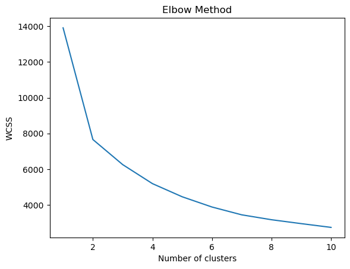

```python
plt.plot(range(1, 11), wcss)
plt.title('Elbow Method')
plt.xlabel('Number of clusters')
plt.ylabel('WCSS')
plt.show()
```

```python
optimal_number_of_clusters=3
kmeans = KMeans(n_clusters=optimal_number_of_clusters, random_state=0)
cluster_labels = kmeans.fit_predict(scaled_features)
```

```python
dt['Cluster'] = cluster_labels

print(dt.groupby('Cluster').mean())
```

```
          Unnamed: 0            X           No      Plot  Light_ISF  \
Cluster
0        1170.133648  1169.133648  3949.496855  9.642296   0.085875
1        1519.001905  1518.001905  3841.339048  9.388571   0.084620
2        1714.911063  1713.911063  3984.655098  9.733189   0.087718

                Core        AMF       EMF  Phenolics     Lignin        NSC  \
Cluster
0        2016.694182  17.004536  0.250448   3.946022  22.233915  17.602995
1        2016.614286  15.886543  0.845714   0.039095  11.155210  11.524238
2        2016.603037  40.972993  0.826464   0.692928   8.383926  11.023427

            Census       Time     Event
Cluster
0        19.173742  67.108097  0.250448
1        12.041905  42.146667  0.845714
2        11.924078  41.734273  0.826464
```

**Means of Features by Cluster**:

**Differences in Other Features**:

- **'Core'** is approximately the same across all clusters, which indicates it might not be a differentiating factor.
- **'AMF'** is notably higher in Cluster 2, which might have some ecological or environmental implications.
- **'EMF', 'Phenolics', 'Lignin', and 'NSC'** also vary across clusters. For instance, **'Phenolics' and 'Lignin'** are highest in Cluster 0, which could suggest differences in tree species, age, or health.

## Tryout1- Classification / Decision Tree

```python
print(dt['Phenolics'].min(),
dt['Phenolics'].max())
```

```
-1.35 6.1
```

```python
dt = dt[dt['Event'].isin([0, 1])]
dt['Pheno_cat']=0
dt.loc[dt['Phenolics']>1.15,'Pheno_cat']=1
dt.loc[dt['Phenolics']>3.63,'Pheno_cat']=2
```

```python
from sklearn.model_selection import train_test_split
from sklearn.tree import DecisionTreeClassifier
from sklearn import svm
from sklearn.svm import SVC
from sklearn.metrics import classification_report
from sklearn.metrics import accuracy_score, precision_score, recall_score, f1_score
y=dt[['Event']]
X_encoded = pd.get_dummies(dt[['Species', 'Light_Cat', 'Soil', 'Sterile','Pheno_cat']], drop_first=True)
X_train, X_test, y_train, y_test = train_test_split(X_encoded, y, test_size=0.2, random_state=42)
```

```python
cl_mdl= DecisionTreeClassifier(random_state=0)
cl_mdl.fit(X_train, y_train)
cl_pred = cl_mdl.predict(X_test)
```

```python
print("Accuracy of Decision Tree Classifier: ",
      accuracy_score(y_test, cl_pred))
print("Precision of Decision Tree Classifier: ",
      precision_score(y_test, cl_pred, average='weighted'))
print("Recall of Decision Tree Classifier: ",
      recall_score(y_test, cl_pred, average='weighted'))
print("F1-Score of Decision Tree Classifier: ",
      f1_score(y_test, cl_pred, average='weighted'))
```

```
Accuracy of Decision Tree Classifier:  0.8168761220825853
Precision of Decision Tree Classifier:  0.8251828827138991
Recall of Decision Tree Classifier:  0.8168761220825853
F1-Score of Decision Tree Classifier:  0.8179907539202854
```

```python
print(classification_report(y_test, cl_pred))
```

```
              precision    recall  f1-score   support

         0.0       0.75      0.85      0.80       234
         1.0       0.88      0.79      0.83       323

    accuracy                           0.82       557
   macro avg       0.81      0.82      0.82       557
weighted avg       0.83      0.82      0.82       557
```

```python
clf = svm.SVC()
clf.fit(X_train, y_train)
clf_pred = clf.predict(X_test)
print("Accuracy of SVM Classifier: ",
      accuracy_score(y_test, clf_pred))
print("Precision of SVM Classifier: ",
      precision_score(y_test, clf_pred, average='weighted'))
print("Recall of SVM Classifier: ",
      recall_score(y_test, clf_pred, average='weighted'))
print("F1-Score of SVM Classifier: ",
      f1_score(y_test, clf_pred, average='weighted'))
```

```
Accuracy of SVM Classifier:  0.8276481149012568
Precision of SVM Classifier:  0.8351532276062085
Recall of SVM Classifier:  0.8276481149012568
F1-Score of SVM Classifier:  0.8286721208895959
```

```python
print(classification_report(y_test, clf_pred))
```

```
              precision    recall  f1-score   support

         0.0       0.76      0.86      0.81       234
         1.0       0.89      0.80      0.84       323

    accuracy                           0.83       557
   macro avg       0.82      0.83      0.83       557
weighted avg       0.84      0.83      0.83       557
```

## Prediction Result

#### The Decision Tree Classifier

This model achieved an accuracy of approximately 81.69%, with precision at around 82.52%. The recall and F1-score were also in the same range, at 81.69% and 81.80% respectively. These metrics suggest that the Decision Tree Classifier performed well, correctly identifying a high percentage of events, with a balanced trade-off between precision (the ability to identify only relevant instances) and recall (the ability to identify all relevant instances).

#### Summary

Both classifiers performed with high accuracy, precision, recall, and F1-scores, with the SVM Classifier slightly outperforming the Decision Tree Classifier on this particular dataset. These results suggest that for predicting the 'Event' variable, the chosen features and model training approach were effective. The slightly higher scores for the SVM Classifier may indicate its better suitability for handling the complexity or the specific patterns present in the dataset.